# Introduction - Data Visualisation with R

Marco Lax

Summer term 2023

# Welcome to the Data Visualization Course with R at the University of Constance

In the era of data-driven decision-making, the ability to effectively communicate complex information through visual representation is becoming a crucial skill across all disciplines. Are you ready to unlock the power of data visualization and transform social data sets into compelling, insightful visual stories?

Our cutting-edge Data Visualization Course with R is tailored to equip you with the essential knowledge and practical skills needed to create stunning visualizations that transcend the boundaries of traditional data analysis. Whether you’re a social scientist, researcher, business professional, or a data enthusiast, this course offers an immersive journey into the world of data visualization using the powerful R programming language.

## What You’ll Learn:

- Fundamentals of data visualization principles and best practices.
- Data wrangling and preparation for visualization.
- R programming essentials for data visualization.
- Exploratory data analysis techniques.
- Creating static and interactive visualizations with ggplot2 and other R packages.
- Storytelling with data and effective communication through visualization.

## Prerequisites:

Participants should have a basic understanding of data analysis concepts and some familiarity with R programming. Don’t worry if you’re not an expert in R; we’ll cover the essential aspects to get you up and running.

Don’t miss this opportunity to transform your data into captivating visual stories that make a difference! Enroll in our Data Visualization Course with R today and embark on an exciting journey towards becoming a data visualization expert.

### R Packages

**How to Install Packages in R**

In R, packages are essential tools that extend the functionality of the base R language, allowing you to access additional functions and capabilities for various tasks. Installing packages is a straightforward process using the `install.packages()` function.

To install a package, open R or RStudio and follow these steps:

1. **Install a Single Package:**

To install a single package, use the `install.packages()` function with the name of the package enclosed in quotes:

```r
#install.packages("ggplot2")
```

This example installs the popular data visualization package “ggplot2.”

3. **Install Multiple Packages:**

You can install multiple packages simultaneously by providing a vector of package names:

```r
#install.packages(c("tidyr","dplyr"))
```

6. **Load Installed Package:**

Once the package is installed, load it into your R session using the `library()` or `require()` function:

```r
library(ggplot2)
```

Now you’re ready to utilize the functions and capabilities of the installed package in your R code.

With these simple steps, you can easily install packages in R, expanding your data analysis and visualization toolkit to suit your needs. Happy coding!

### Basic Syntax of ggplot2

To start creating visualizations with ggplot2, you need to follow a consistent syntax pattern:

```r
# Sample dataset
data <- data.frame(x = c(1, 2, 3, 4, 5),
                   y = c(2, 4, 1, 5, 3))
```

Now, we can create a scatter plot:

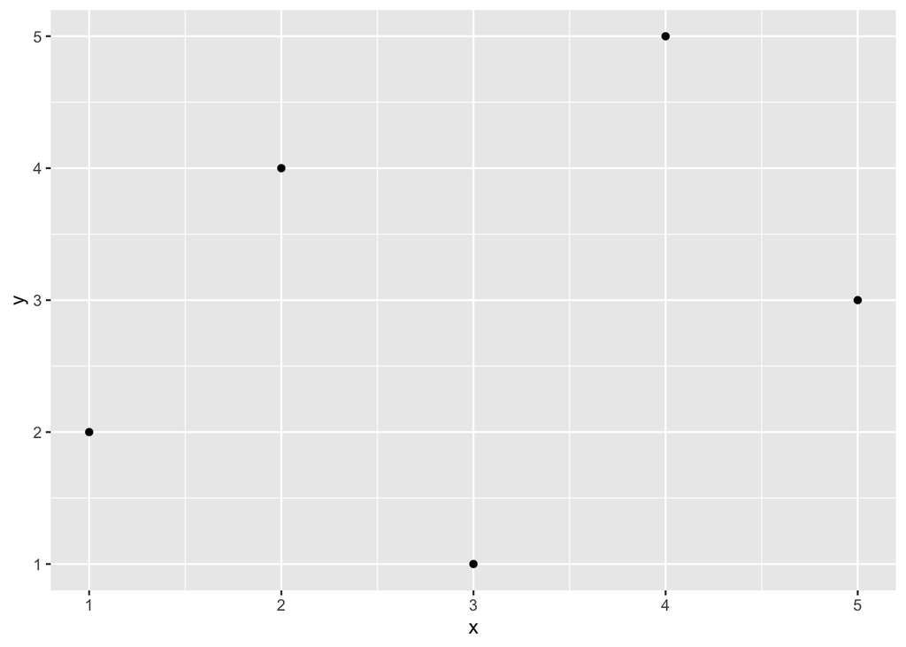

```r
ggplot(data = data) +
  geom_point(mapping = aes(x = x, y = y))
```

In this example:

data = data specifies the dataset we want to use. geom_point() indicates that we want to create a scatter plot. mapping = aes(x = x, y = y) defines the aesthetic mappings, associating the x variable with the x-axis and the y variable with the y-axis. Customizations

ggplot2 offers a wide range of customizations to enhance your visualizations. You can add labels, change colors, adjust axis scales, and much more.

For instance, let’s customize the scatter plot by adding a title and changing the point color:

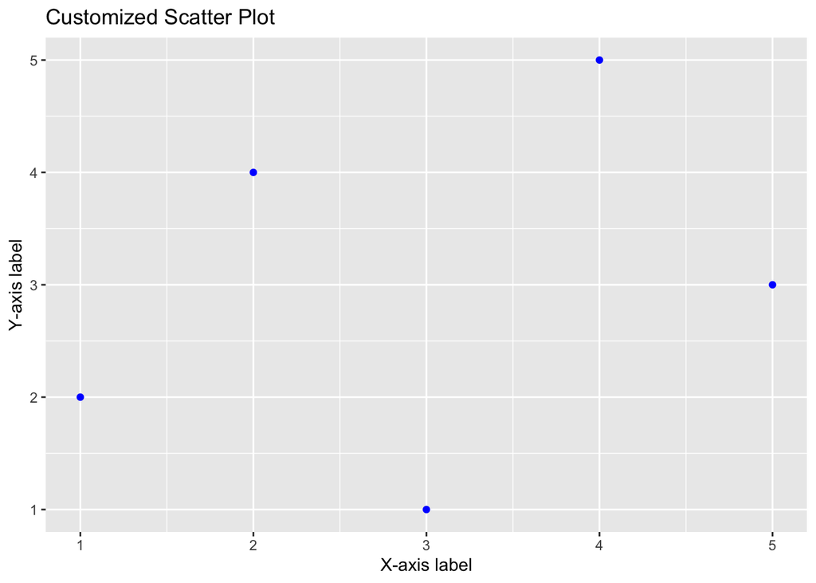

```r
ggplot(data = data) +
  geom_point(mapping = aes(x = x, y = y), color = "blue") +
  labs(title = "Customized Scatter Plot", x = "X-axis label", y = "Y-axis label")
```

Here, we added color = “blue” inside geom_point() to change the point color, and labs() to set the title and axis labels.